# Regional Data Dashboard for COVID-19 Response Funds: Grantmaking Analytics

### Cumberland County, New Jersey *An atlas of COVID-19 era need and philanthropic response for the Southeastern Pennsylvania/Southern New Jersey region*

#### July 2020

The maps on this site are part of the [Regional Data Dashboard for COVID-19 Response Fund](https://www.impact.upenn.edu/toolkits/regional-dashboard/) hosted at the Center for High Impact Philanthropy to chronicle philanthropic efforts to battle COVID-19 in Southeastern Pennsylvania and Southern New Jersey.

This report provides strategic planning intelligence to philanthropies making placed-based investments in the wake of COVID-19. The goal is to understand where the supply of resources are aligned with the demand for those resources, and where they are not. Philanthropies can then use this intelligence to plan future investments.

This report is part of a larger effort to chronicle philanthropic efforts to battle COVID-19 in the Delaware Valley Region.

The next section provides additional grantmaking analytics. Section 2 visualizes a series of grantmaking planning overlay maps intended to help philanthropies working in Cumberland County identify areas where need currently outweighs grant resources. The remaining sections include additional analytics. Worth noting is the Employment section, which visualizes the geography of COVID-related unemployment.

## 1. Grantmaking

The maps throughout this report contain grants georeferenced in two ways. Some grants are referenced by the *Service Area* where resources were expended. Other grants were referenced by the address of the *Organizations* or *Individuals* who received grants. We have tried to label analytics in this section to convey these differences.

### 1.1 What *service areas* are receiving more grants?

[figure not shown]

### 1.2 What *service areas* are awarded grants by organizational mission?

[figure not shown]

### 1.3 Where are *organizations* who are receiving grants located?

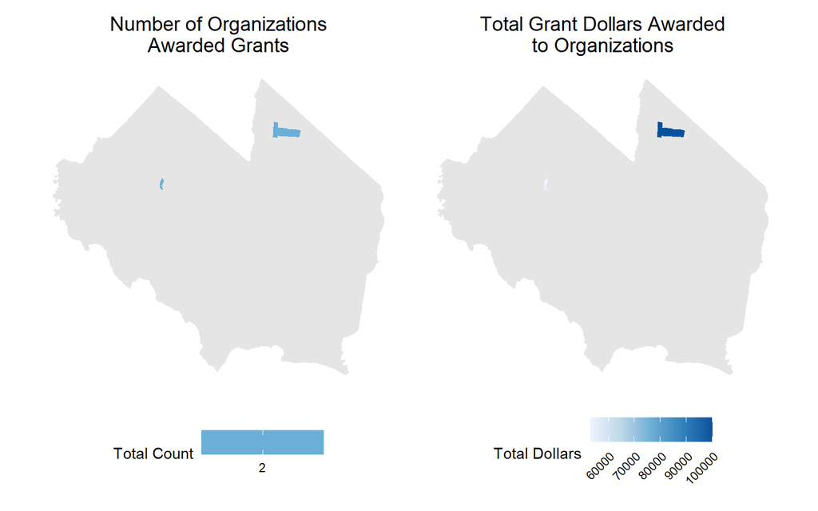

### 1.4 Where are *individuals* who are receiving grants located?

[figure not shown]

### 1.5 Breakdown of *organization* grants by funder

*This plot has temporarily been redacted until further consideration by the funds whose data is represented here.*

### 1.6 How much funding was allocated by mission and by fund?

*This plot has temporarily been redacted until further consideration by the funds whose data is represented here.*

## 2. Strategic Planning Overlays

The goal of these map overlays is to help stakeholders understand if resources are being allocated *where* they are needed most. Philanthropies should consider targeting future investment in places where relative need exceeds grantmaking. The overlays visualize grant data by the *service area*.

Housing instability and social vulnerability indices define the geography of need in Cumberland County. Housing instability is a composite that describes the number of renters, the number of renters paying more than 30% of their income on rent (ie. ‘rent burdened’), and the current tract-level unemployment rate.[^1]

Social vulnerability is a composite of rent burdened households, single-parent households, tract-level poverty rate, percent receiving SNAP benefits, and percent without health insurance. Below, need and grantmaking are visualized side-by-side and with cartographic overlays. Again, these overlays highlight areas where more investment may be needed.

### 2.1 Social vulnerability & grantmaking maps

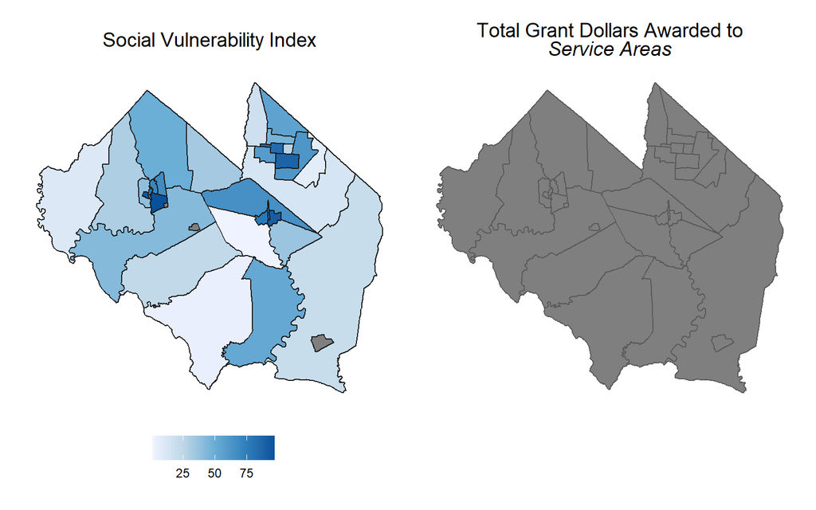

### 2.2 Social vulnerability & grantmaking overlay

Census tracts visualized in darker blue, are those where relative social vulnerability is greater than relative grantmaking. Shades of white indicate better balance between relative need and grantmaking. Darker shades of red are places where there is more relative grantmaking compared to need. Perform this analysis on your are of interest using the [Strategic Planning Tool](https://urbanspatial.github.io/COVIDPlanning/#strategic-planning-tool).

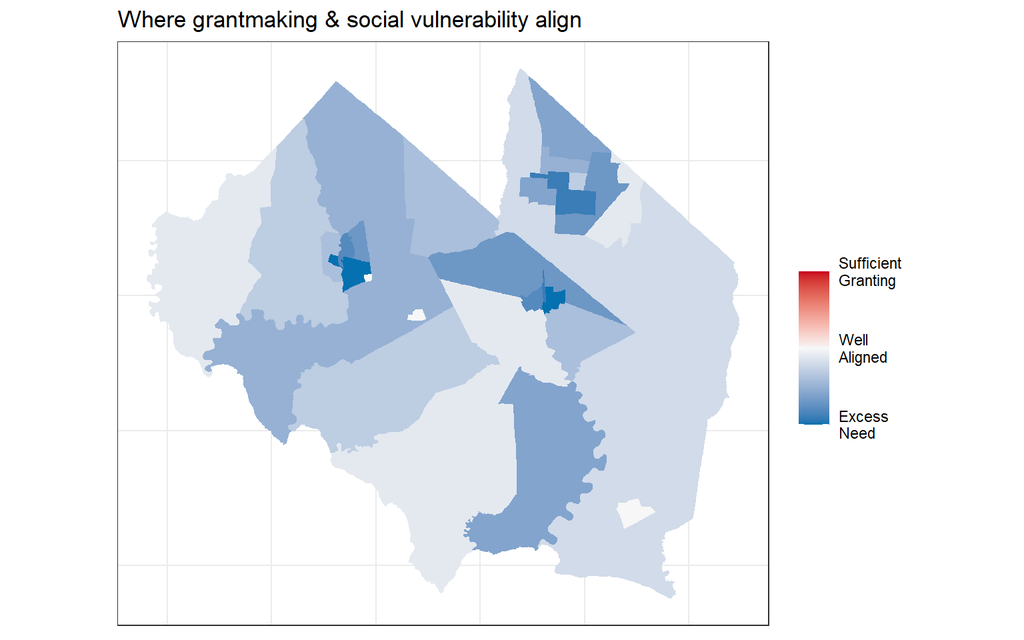

### 2.3 Housing instability & grantmaking maps

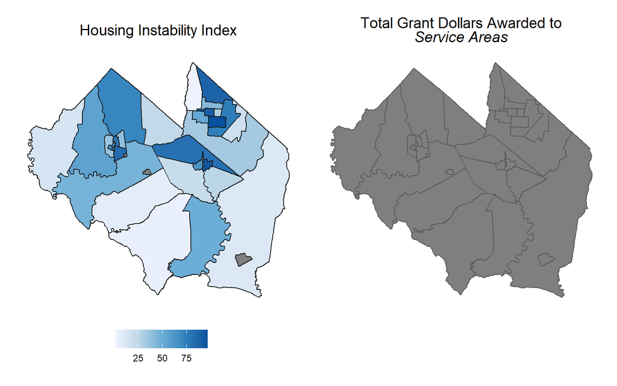

### 2.4 Housing instability & grantmaking overlay

Again, Census tracts visualized in darker blue, are those where relative housing instability is greater than relative grantmaking. Shades of white indicate better balance between relative need and grantmaking. Darker shades of red are places where there is more relative grantmaking compared to need. Perform this analysis on your are of interest using the [Strategic Planning Tool](https://urbanspatial.github.io/COVIDPlanning/#strategic-planning-tool)

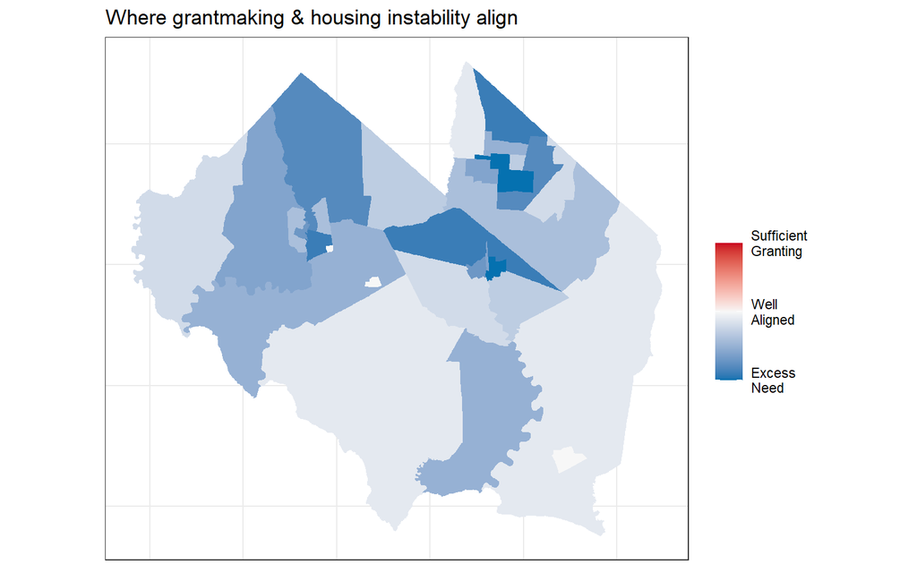

## 3. Housing

With respect to housing in Cumberland County, New Jersey, the average tract-level median rent is $850.03. The average rate of owner occupied housing is 61%. In 77% of tracts, at least half of households are rent burdened.

The maps below provide a detailed look at housing in Cumberland County.

### 3.1 Where do rent burdened households live?

Rent burdened households are those spending more than 30% of their income on housing. The map below visualizes percent rent burdened by tract.

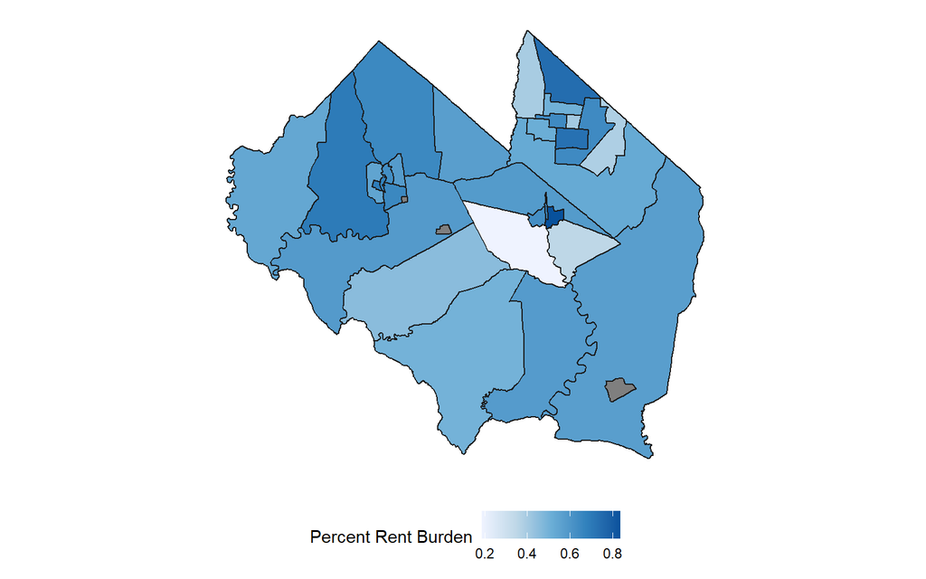

### 3.2 Where are owner-occupied households concentrated?

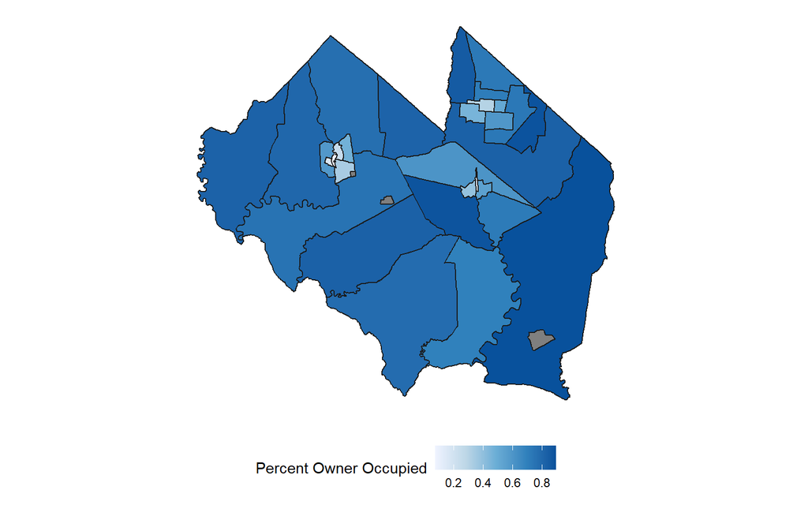

### 3.3 How does rent vary across Cumberland County?

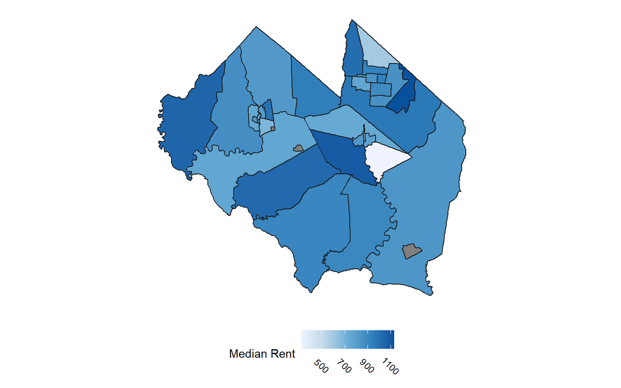

### 3.4 Where do renters rely on alternative travel mode choices?

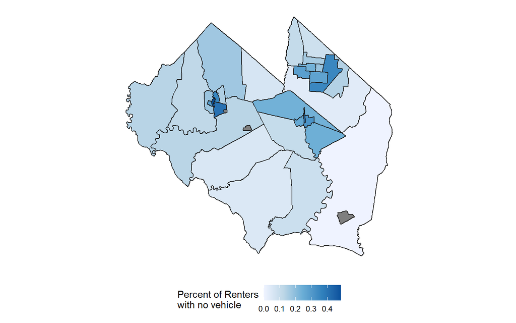

### 3.5 Cumberland County transit deserts

The map below visualizes the distance in miles from each tract to its nearest transit station.

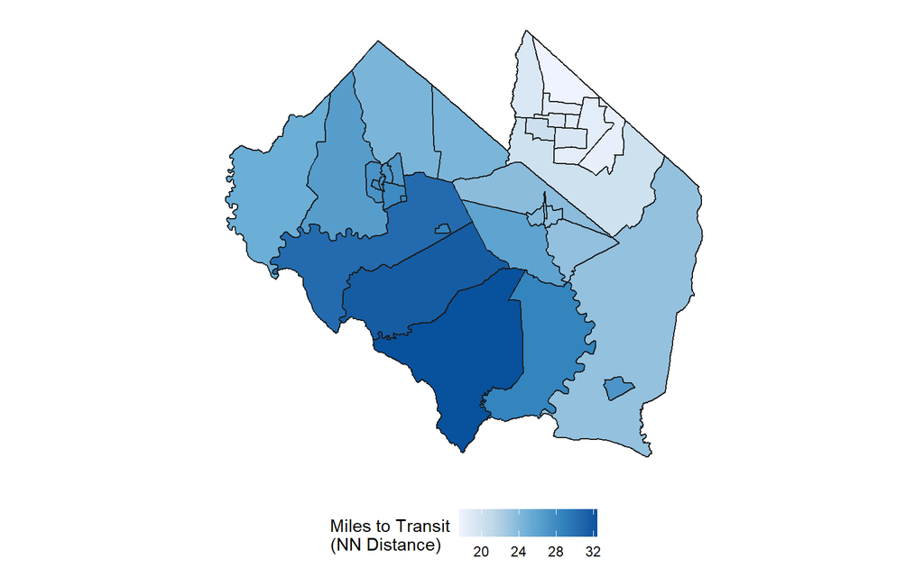

## 4. Demographics

In Cumberland County, New Jersey, the average median household income is $52,370.55 and the average population density is 2,632 people per square mile. The mean poverty rate is 19%, with the highest poverty rate, areawide, being 51%.

Below a host of demographic-related maps are presented.

### 4.1 How does population density vary across Cumberland County?

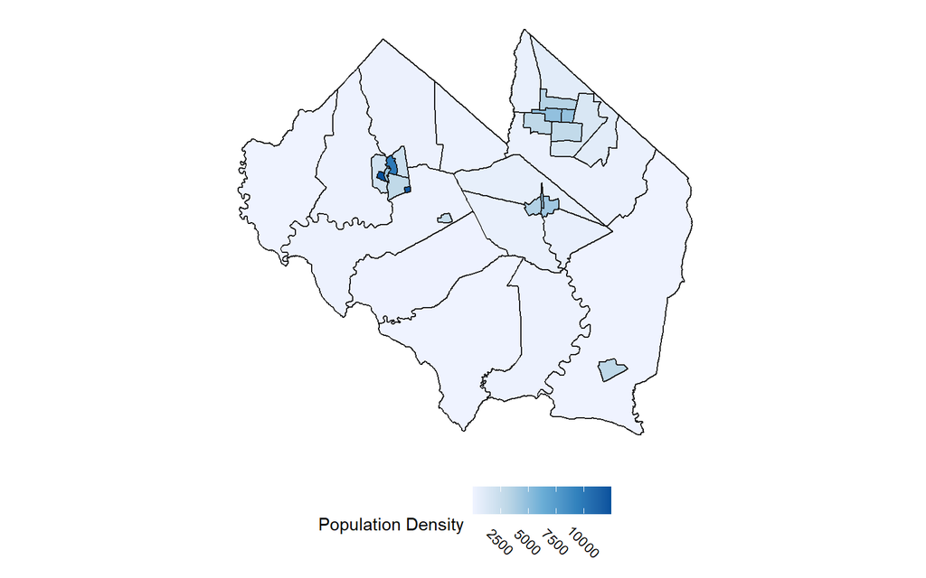

### 4.2 Median Household Income

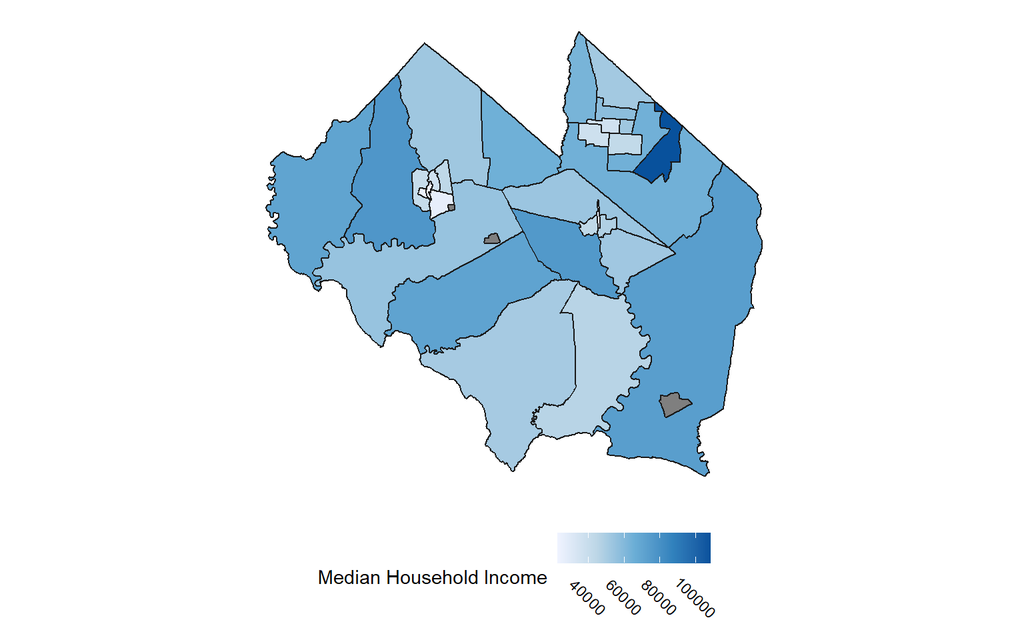

### 4.3 Poverty-rate across Cumberland County

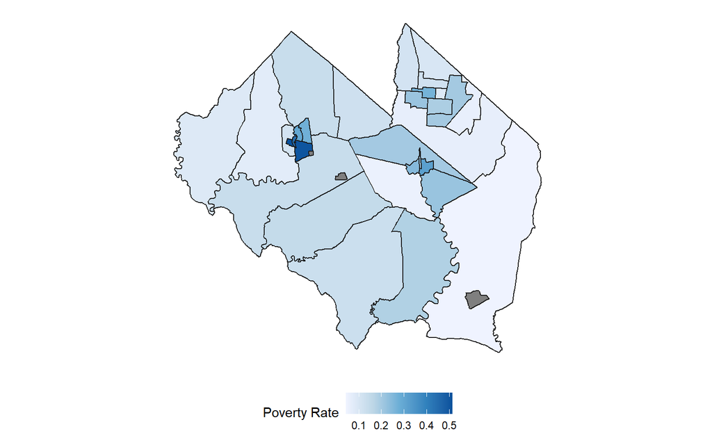

### 4.4 Percent non-white households

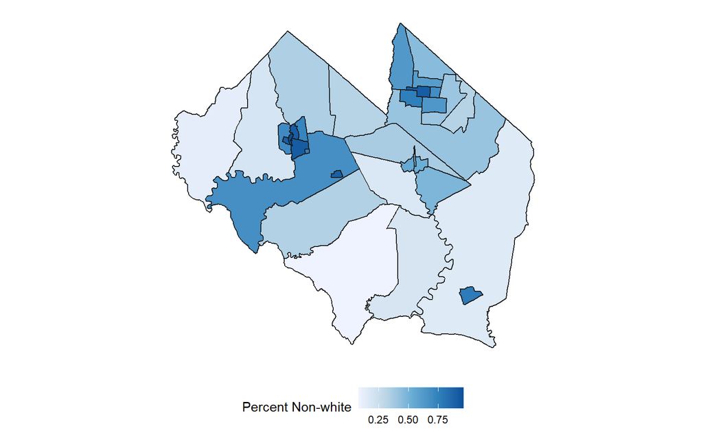

### 4.5 Individuals aged 65+

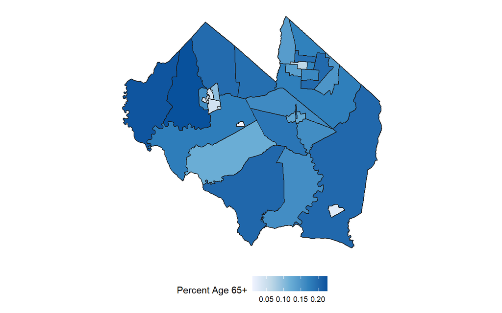

### 4.6 Individuals aged under 18

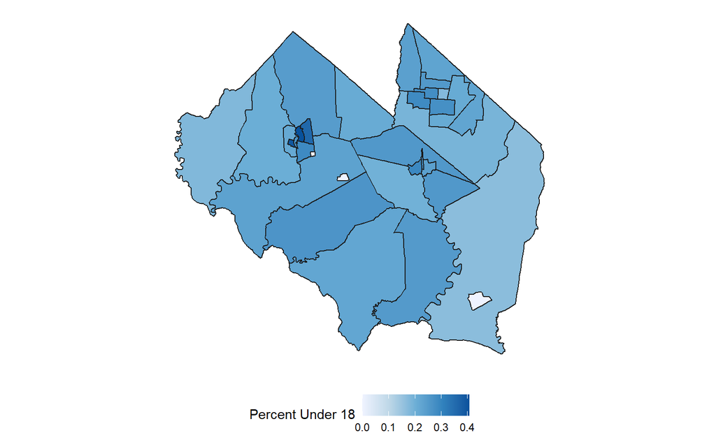

### 4.7 Children under age 6

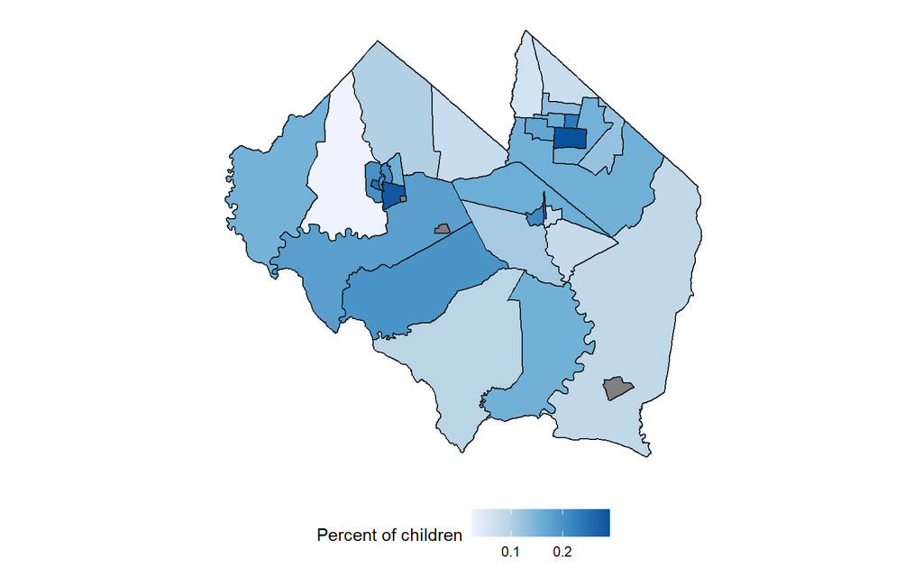

### 4.8 Access to childcare

The map below visualizes the distance in miles from each tract to its nearest childcare center.

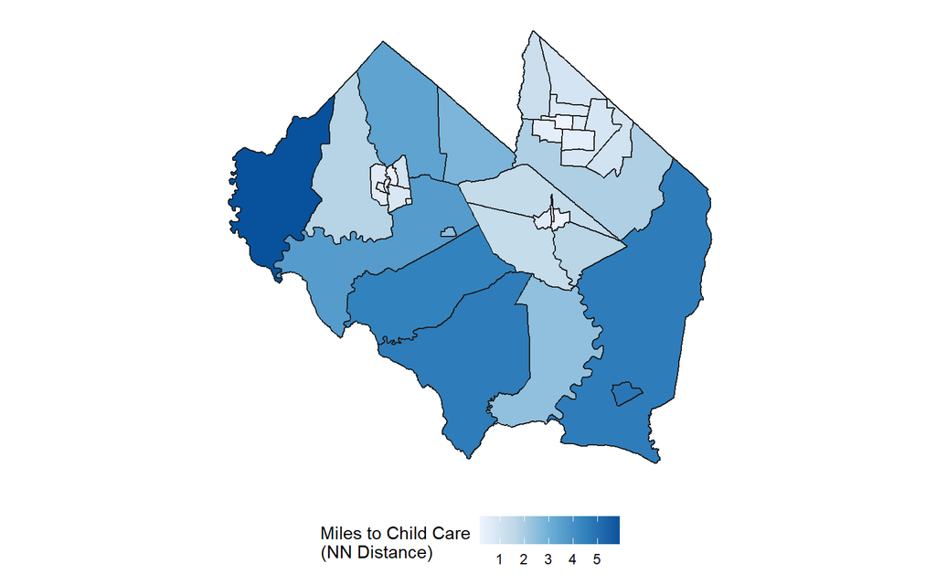

## 5. Employment

In this section, labor force participation is visualized along with recent changes that have resulted from COVID-19.

The average rate of individuals who have attained at least a high school degree in Cumberland County, New Jersey is 77%. In 2015, the Census estimated that 63,646 individuals were employed, which represents 67% of adults. As of mid May, 2020, the estimated average tract-level unemployment rate was 7% meaning an estimated 4,642 fewer individuals were employed at that time.

The geography of COVID-19 unemployment is explored further below.

### 5.1 Education attainment: High school degree and higher

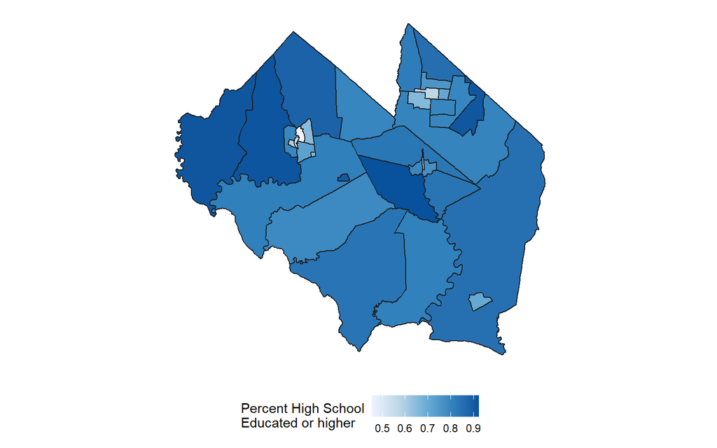

### 5.2 Total labor force

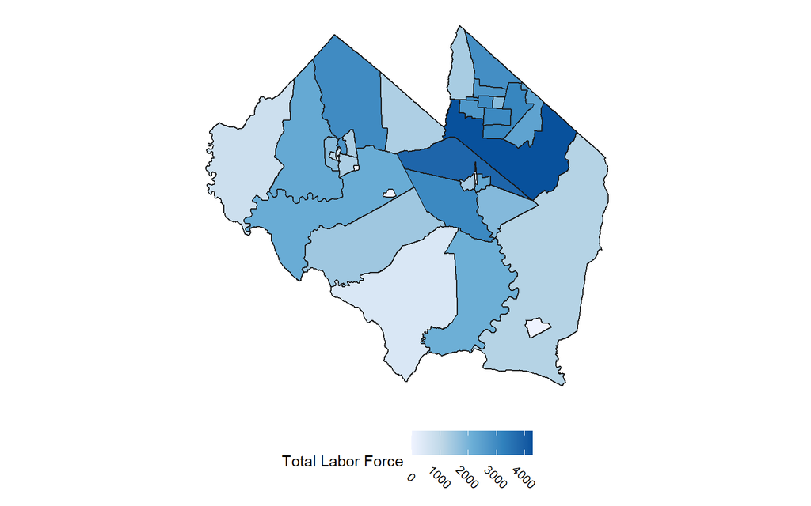

### 5.3 Where do workers live by sector (2018)

Using Census LODES data, the below set of maps show where Cumberland County, New Jersey workers in select sectors live.

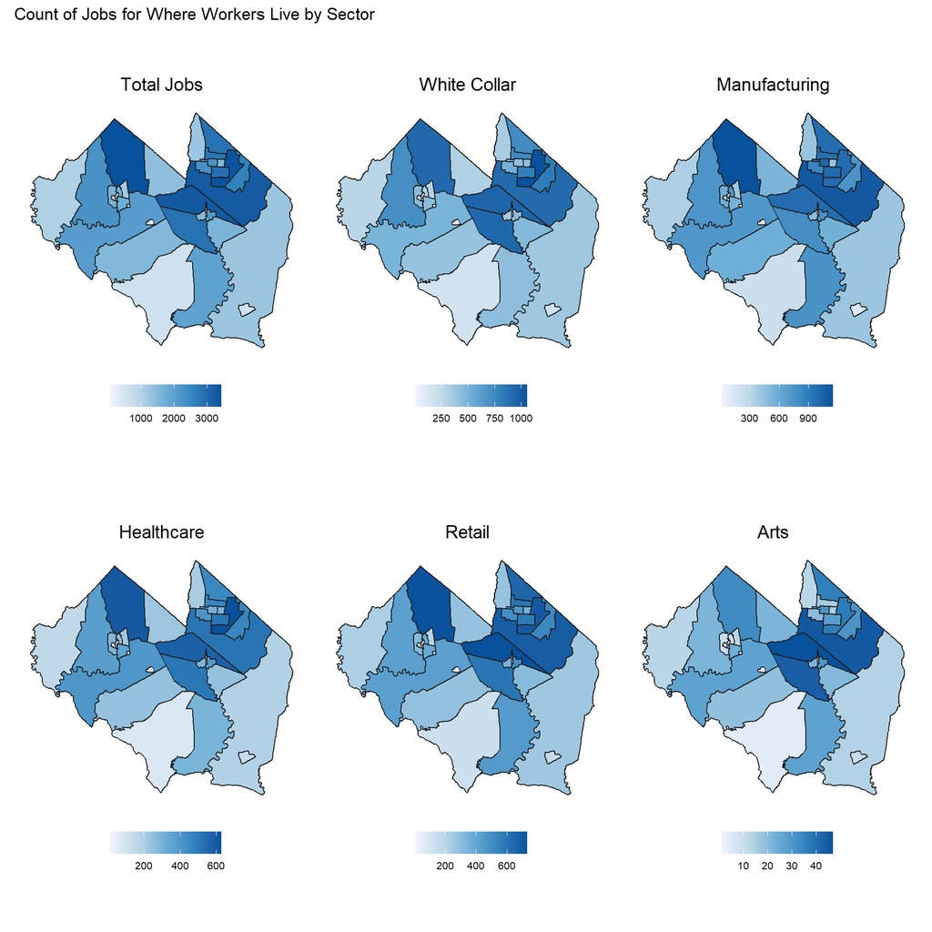

### 5.4 Estimated unemployment by sector

Combining tract-level employment counts from Census LODES with tract-level *unemployment* estimates from the BLS allows estimates for where employment-vulnerable workers live in Cumberland County, New Jersey.

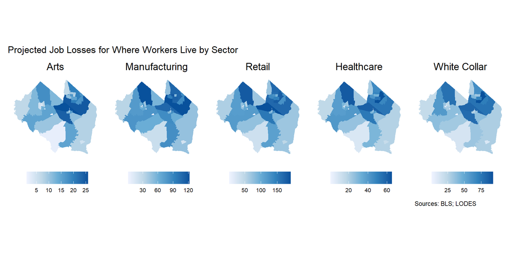

## 6. Food Insecurity

In Cumberland County, New Jersey, the average rate of households receiving food assistance is 19%. The average rate of households with children receiving food assistance areawide is 11%.

Below, food insecurity and food access in Cumberland County is mapped.

### 6.1 Where do households receive food assistance?

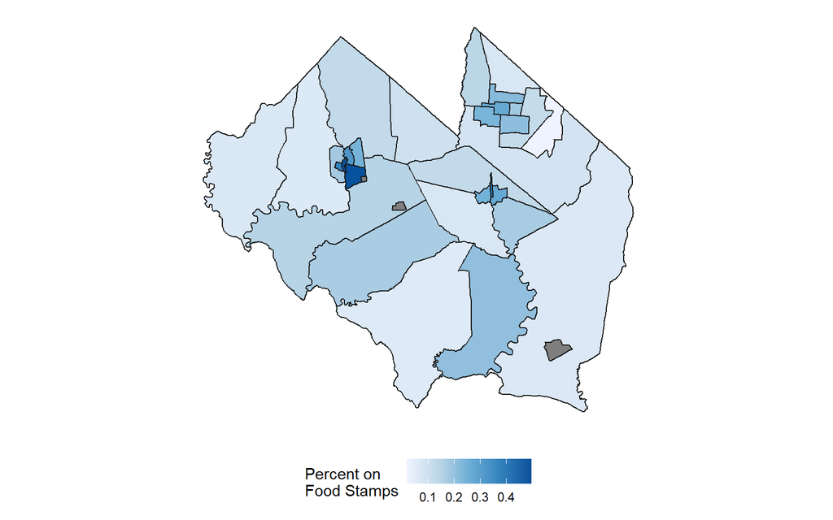

### 6.2 Where do households with children receive food assistance?

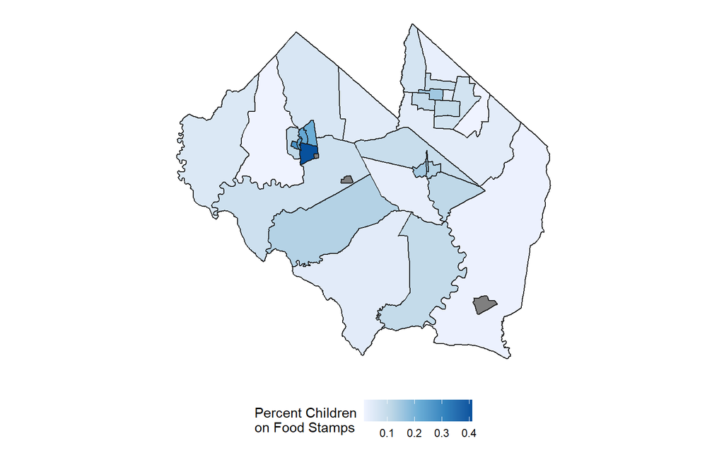

### 6.3 Cumberland County food deserts

The map below visualizes the rate of low income households who live more than 1/2 mile from a supermarket in urban areas and more than 10 miles in rural areas.

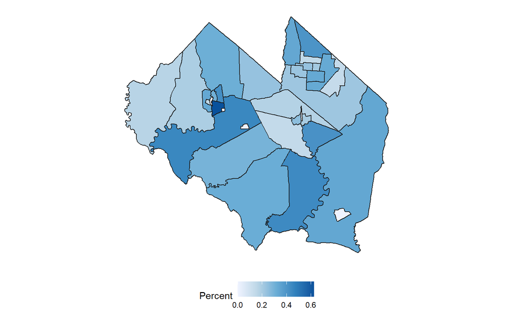

## 7. Health

The average health insured rate for households in Cumberland County, New Jersey is 89%. The average rate of disabled residents is 15%.

Several health-related indicators are mapped below.

### 7.1 Rate of health insured

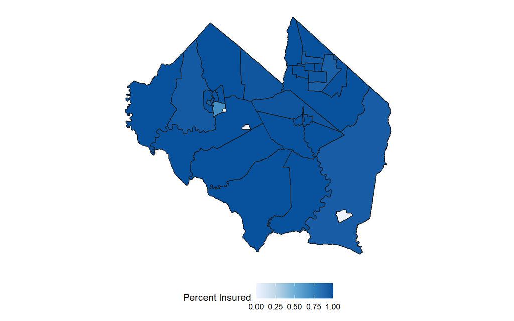

### 7.2 Rate of disabled

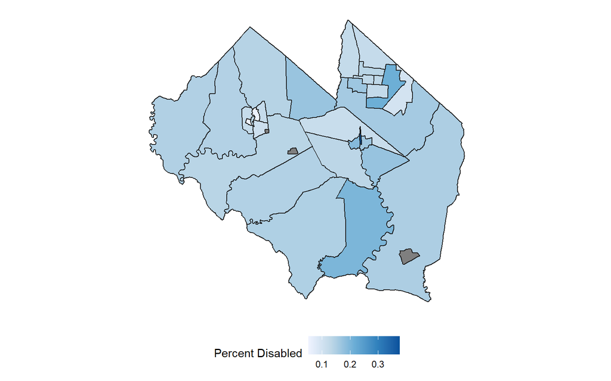